# Electric Field Lines — Student Worksheet

**Unit: Electrostatics — Lesson 06** Name: _______________________ Date: __________ Period: ____

## Phenomenon

Your teacher switches on two electrodes in a dish of semolina grains in oil. The grains snap into curved chains running between the electrodes — an invisible field suddenly made visible.

**Driving question:** What rules do field lines follow, and how do they show us the direction and strength of an electric field?

## Notice & Wonder

| I notice… | I wonder… |
| --- | --- |

**Turn & Talk #1:** From the semolina chains, write **two rules** the field lines seem to obey.

> Rule 1: __________________________________________ Rule 2: __________________________________________

## Initial Model

Draw a single **+** charge and sketch how you think the field lines leave it. Then draw a **+** and a **−** near each other and sketch the lines between them.

## Investigation

Use the Javalab field-line sim to build three patterns. Record what you notice.

| Setup | Where lines start / end | Spacing (even? bunched?) | Field strongest where? |
| --- | --- | --- | --- |
| 1. Single + charge |  |  |  |
| 2. Dipole (+ and −) |  |  |  |
| 3. Parallel plates |  |  |  |

Confirm each against these diagrams:

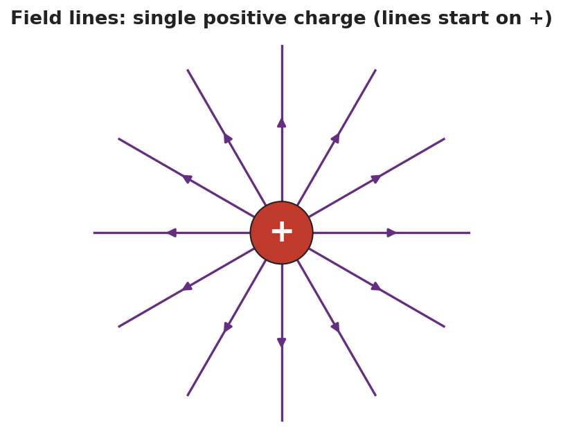

Field lines radiating outward from a single positive charge.

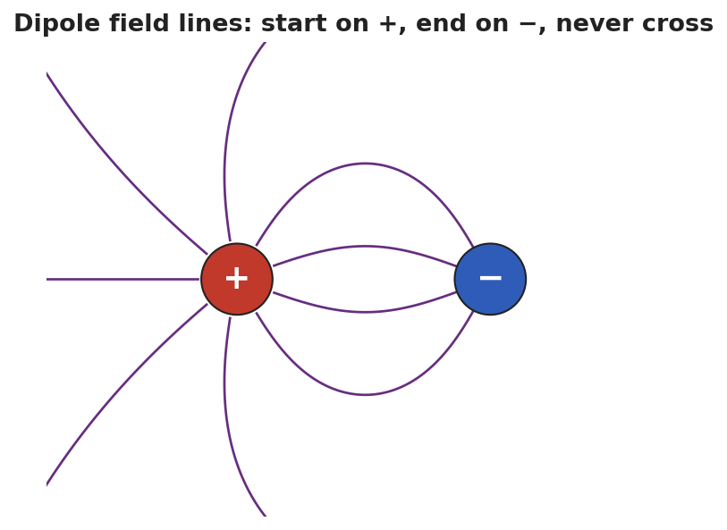

Dipole field lines curving from + to −, never crossing.

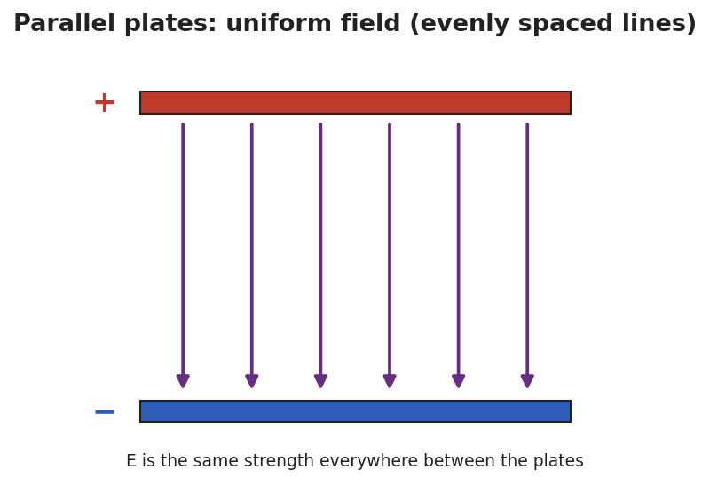

Parallel plates with straight, evenly spaced field lines — a uniform field.

**Key question:** Why can’t two field lines ever cross?

## Make It Make Sense

1. List the four rules for drawing electric field lines.
2. Two diagrams show field lines: in Diagram A the lines are close together; in Diagram B they are far apart. Where is the field stronger, and how do you know?
3. How is the field between parallel plates different from the field around a single charge?

## Vocabulary in Action

Use each term in a sentence about today’s phenomenon.

- **field line:** _______________________________________________
- **dipole:** _______________________________________________
- **uniform field:** _______________________________________________

## Revise Your Model

Return to your dipole sketch. Re-draw it to obey **all four rules**: lines start on +, end on −, never cross, and crowd where the field is strong. Label where the field is strongest.

## Exit Ticket

1. State **two** rules for drawing electric field lines.
2. Two diagrams show field lines: in Diagram A the lines are close together; in Diagram B they are spread far apart. Where is the field stronger, and how do you know?
3. Sketch the field lines for a single **negative** charge. Which way do the arrows point, and where do they end?